# Optimal Treatment Analysis

## Outcome Variable

**Outcome Variable:** whz

## Predictor Variables

**Intervention Variable:** exclfeed6

**Adjustment Set:**

- arm
- sex
- W_mage
- meducyrs
- feducyrs
- hhwealth_quart
- hfoodsec
- W_mhtcm
- vagbrth
- W_gagebrth
- W_birthwt
- W_birthlen
- W_nrooms
- W_nchldlt5
- month
- brthmon
- W_parity
- impfloor
- impsan
- safeh20
- delta_W_mage
- delta_meducyrs
- delta_feducyrs
- delta_hhwealth_quart
- delta_hfoodsec
- delta_W_mhtcm
- delta_vagbrth
- delta_W_gagebrth
- delta_W_birthwt
- delta_W_birthlen
- delta_W_nrooms
- delta_W_nchldlt5
- delta_month
- delta_brthmon
- delta_W_parity
- delta_impfloor
- delta_impsan
- delta_safeh20

## Stratifying Variables

The analysis was stratified on these variable(s):

- agecat
- studyid
- country

## Data Summary

| agecat | studyid | country | exclfeed6 | n_cell | n |
| --- | --- | --- | --- | --- | --- |
| Birth | ki0047075b-MAL-ED | BANGLADESH | 1 | 53 | 219 |
| Birth | ki0047075b-MAL-ED | BANGLADESH | 0 | 166 | 219 |
| Birth | ki0047075b-MAL-ED | BRAZIL | 1 | 11 | 168 |
| Birth | ki0047075b-MAL-ED | BRAZIL | 0 | 157 | 168 |
| Birth | ki0047075b-MAL-ED | INDIA | 1 | 5 | 187 |
| Birth | ki0047075b-MAL-ED | INDIA | 0 | 182 | 187 |
| Birth | ki0047075b-MAL-ED | NEPAL | 1 | 11 | 165 |
| Birth | ki0047075b-MAL-ED | NEPAL | 0 | 154 | 165 |
| Birth | ki0047075b-MAL-ED | PERU | 1 | 10 | 249 |
| Birth | ki0047075b-MAL-ED | PERU | 0 | 239 | 249 |
| Birth | ki0047075b-MAL-ED | SOUTH AFRICA | 1 | 0 | 209 |
| Birth | ki0047075b-MAL-ED | SOUTH AFRICA | 0 | 209 | 209 |
| Birth | ki0047075b-MAL-ED | TANZANIA, UNITED REPUBLIC OF | 1 | 1 | 115 |
| Birth | ki0047075b-MAL-ED | TANZANIA, UNITED REPUBLIC OF | 0 | 114 | 115 |
| Birth | ki1000108-CMC-V-BCS-2002 | INDIA | 1 | 7 | 7 |
| Birth | ki1000108-CMC-V-BCS-2002 | INDIA | 0 | 0 | 7 |
| Birth | ki1000108-IRC | INDIA | 1 | 0 | 12 |
| Birth | ki1000108-IRC | INDIA | 0 | 12 | 12 |
| Birth | ki1000109-EE | PAKISTAN | 1 | 0 | 1 |
| Birth | ki1000109-EE | PAKISTAN | 0 | 1 | 1 |
| Birth | ki1000304b-SAS-CompFeed | INDIA | 1 | 45 | 47 |
| Birth | ki1000304b-SAS-CompFeed | INDIA | 0 | 2 | 47 |
| Birth | ki1101329-Keneba | GAMBIA | 1 | 451 | 1336 |
| Birth | ki1101329-Keneba | GAMBIA | 0 | 885 | 1336 |
| Birth | kiGH5241-JiVitA-3 | BANGLADESH | 1 | 12371 | 15420 |
| Birth | kiGH5241-JiVitA-3 | BANGLADESH | 0 | 3049 | 15420 |
| Birth | kiGH5241-JiVitA-4 | BANGLADESH | 1 | 519 | 633 |
| Birth | kiGH5241-JiVitA-4 | BANGLADESH | 0 | 114 | 633 |
| 6 months | ki0047075b-MAL-ED | BANGLADESH | 1 | 57 | 235 |
| 6 months | ki0047075b-MAL-ED | BANGLADESH | 0 | 178 | 235 |

[output cut: 64 more lines]

The following strata were considered:

- agecat: 24 months, studyid: ki0047075b-MAL-ED, country: BANGLADESH
- agecat: 24 months, studyid: ki0047075b-MAL-ED, country: BRAZIL
- agecat: 24 months, studyid: ki0047075b-MAL-ED, country: INDIA
- agecat: 24 months, studyid: ki0047075b-MAL-ED, country: NEPAL
- agecat: 24 months, studyid: ki0047075b-MAL-ED, country: PERU
- agecat: 24 months, studyid: ki0047075b-MAL-ED, country: SOUTH AFRICA
- agecat: 24 months, studyid: ki0047075b-MAL-ED, country: TANZANIA, UNITED REPUBLIC OF
- agecat: 24 months, studyid: ki1000108-CMC-V-BCS-2002, country: INDIA
- agecat: 24 months, studyid: ki1000108-IRC, country: INDIA
- agecat: 24 months, studyid: ki1017093b-PROVIDE, country: BANGLADESH
- agecat: 24 months, studyid: ki1101329-Keneba, country: GAMBIA
- agecat: 24 months, studyid: ki1113344-GMS-Nepal, country: NEPAL
- agecat: 24 months, studyid: ki1148112-LCNI-5, country: MALAWI
- agecat: 24 months, studyid: kiGH5241-JiVitA-3, country: BANGLADESH
- agecat: 24 months, studyid: kiGH5241-JiVitA-4, country: BANGLADESH
- agecat: 6 months, studyid: ki0047075b-MAL-ED, country: BANGLADESH
- agecat: 6 months, studyid: ki0047075b-MAL-ED, country: BRAZIL
- agecat: 6 months, studyid: ki0047075b-MAL-ED, country: INDIA
- agecat: 6 months, studyid: ki0047075b-MAL-ED, country: NEPAL
- agecat: 6 months, studyid: ki0047075b-MAL-ED, country: PERU
- agecat: 6 months, studyid: ki0047075b-MAL-ED, country: SOUTH AFRICA
- agecat: 6 months, studyid: ki0047075b-MAL-ED, country: TANZANIA, UNITED REPUBLIC OF
- agecat: 6 months, studyid: ki1000108-CMC-V-BCS-2002, country: INDIA
- agecat: 6 months, studyid: ki1000108-IRC, country: INDIA
- agecat: 6 months, studyid: ki1000109-EE, country: PAKISTAN
- agecat: 6 months, studyid: ki1000304b-SAS-CompFeed, country: INDIA
- agecat: 6 months, studyid: ki1000304b-SAS-FoodSuppl, country: INDIA
- agecat: 6 months, studyid: ki1017093b-PROVIDE, country: BANGLADESH
- agecat: 6 months, studyid: ki1101329-Keneba, country: GAMBIA
- agecat: 6 months, studyid: ki1113344-GMS-Nepal, country: NEPAL
- agecat: 6 months, studyid: ki1148112-LCNI-5, country: MALAWI
- agecat: 6 months, studyid: kiGH5241-JiVitA-3, country: BANGLADESH
- agecat: 6 months, studyid: kiGH5241-JiVitA-4, country: BANGLADESH
- agecat: Birth, studyid: ki0047075b-MAL-ED, country: BANGLADESH
- agecat: Birth, studyid: ki0047075b-MAL-ED, country: BRAZIL
- agecat: Birth, studyid: ki0047075b-MAL-ED, country: INDIA
- agecat: Birth, studyid: ki0047075b-MAL-ED, country: NEPAL
- agecat: Birth, studyid: ki0047075b-MAL-ED, country: PERU
- agecat: Birth, studyid: ki0047075b-MAL-ED, country: SOUTH AFRICA
- agecat: Birth, studyid: ki0047075b-MAL-ED, country: TANZANIA, UNITED REPUBLIC OF
- agecat: Birth, studyid: ki1000108-CMC-V-BCS-2002, country: INDIA
- agecat: Birth, studyid: ki1000108-IRC, country: INDIA
- agecat: Birth, studyid: ki1000109-EE, country: PAKISTAN
- agecat: Birth, studyid: ki1000304b-SAS-CompFeed, country: INDIA
- agecat: Birth, studyid: ki1101329-Keneba, country: GAMBIA
- agecat: Birth, studyid: kiGH5241-JiVitA-3, country: BANGLADESH
- agecat: Birth, studyid: kiGH5241-JiVitA-4, country: BANGLADESH

### Dropped Strata

Some strata were dropped due to rare outcomes:

- agecat: Birth, studyid: ki0047075b-MAL-ED, country: SOUTH AFRICA
- agecat: Birth, studyid: ki0047075b-MAL-ED, country: TANZANIA, UNITED REPUBLIC OF
- agecat: Birth, studyid: ki1000108-CMC-V-BCS-2002, country: INDIA
- agecat: Birth, studyid: ki1000108-IRC, country: INDIA
- agecat: Birth, studyid: ki1000109-EE, country: PAKISTAN
- agecat: Birth, studyid: ki1000304b-SAS-CompFeed, country: INDIA
- agecat: 6 months, studyid: ki0047075b-MAL-ED, country: SOUTH AFRICA
- agecat: 6 months, studyid: ki0047075b-MAL-ED, country: TANZANIA, UNITED REPUBLIC OF
- agecat: 6 months, studyid: ki1000108-CMC-V-BCS-2002, country: INDIA
- agecat: 6 months, studyid: ki1000108-IRC, country: INDIA
- agecat: 6 months, studyid: ki1000304b-SAS-FoodSuppl, country: INDIA
- agecat: 24 months, studyid: ki0047075b-MAL-ED, country: SOUTH AFRICA
- agecat: 24 months, studyid: ki0047075b-MAL-ED, country: TANZANIA, UNITED REPUBLIC OF
- agecat: 24 months, studyid: ki1000108-CMC-V-BCS-2002, country: INDIA
- agecat: 24 months, studyid: ki1000108-IRC, country: INDIA

## Methods Detail

We’re interested in the causal parameters $E[Y_a]$ for all values of $a \in \mathcal{A}$. These parameters represent the mean outcome if, possibly contrary to fact, we intervened to set all units to have $A=a$. Under the randomization and positivity assumptions, these are identified by the statistical parameters $\psi_a=E_W[E_{Y|A,W}(Y|A=a,W)]$. In addition, we’re interested in the mean of $Y$, $E[Y]$ under no intervention (the observed mean). We will estimate these parameters by using SuperLearner to fit the relevant likelihood factors – $E_{Y|A,W}(Y|A=a,W)$ and $p(A=a|W)$, and then updating our likelihood fit using a joint TMLE.

For unadjusted analyses ($W=\{\}$), initial likelihoods were estimated using Lrnr_glm to estimate the simple $E(Y|A)$ and Lrnr_mean to estimate $p(A)$. For adjusted analyses, a small library containing Lrnr_glmnet, Lrnr_xgboost, and Lrnr_mean was used.

Having estimated these parameters, we will then use the delta method to estimate relative risks and attributable risks relative to a prespecified baseline level of $A$.

# Results Detail

## Results Plots

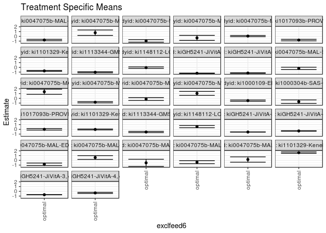

## Results Table

### Parameter: TSM

| agecat | studyid | country | intervention_level | baseline_level | estimate | ci_lower | ci_upper |
| --- | --- | --- | --- | --- | --- | --- | --- |
| Birth | ki0047075b-MAL-ED | BANGLADESH | optimal | observed | -0.8304544 | -1.0913072 | -0.5696017 |
| Birth | ki0047075b-MAL-ED | BRAZIL | optimal | observed | 0.5893934 | 0.1914819 | 0.9873050 |
| Birth | ki0047075b-MAL-ED | INDIA | optimal | observed | -0.5240151 | -1.2730424 | 0.2250121 |
| Birth | ki0047075b-MAL-ED | NEPAL | optimal | observed | -0.3908431 | -0.7084951 | -0.0731911 |
| Birth | ki0047075b-MAL-ED | PERU | optimal | observed | 0.1694542 | -0.3911798 | 0.7300882 |
| Birth | ki1101329-Keneba | GAMBIA | optimal | observed | 1.6203134 | 1.4746956 | 1.7659311 |
| Birth | kiGH5241-JiVitA-3 | BANGLADESH | optimal | observed | -0.7149885 | -0.7363288 | -0.6936483 |
| Birth | kiGH5241-JiVitA-4 | BANGLADESH | optimal | observed | -0.3367892 | -0.4515973 | -0.2219811 |
| 6 months | ki0047075b-MAL-ED | BANGLADESH | optimal | observed | -0.2246756 | -0.4716037 | 0.0222525 |
| 6 months | ki0047075b-MAL-ED | BRAZIL | optimal | observed | 1.3879345 | 0.8381644 | 1.9377046 |
| 6 months | ki0047075b-MAL-ED | INDIA | optimal | observed | -0.8230874 | -0.9516794 | -0.6944954 |
| 6 months | ki0047075b-MAL-ED | NEPAL | optimal | observed | -0.1460442 | -0.4399598 | 0.1478714 |
| 6 months | ki0047075b-MAL-ED | PERU | optimal | observed | 1.0417496 | 0.6273379 | 1.4561613 |
| 6 months | ki1000109-EE | PAKISTAN | optimal | observed | -0.4774173 | -0.6162559 | -0.3385787 |
| 6 months | ki1000304b-SAS-CompFeed | INDIA | optimal | observed | -0.7024985 | -1.0772887 | -0.3277082 |
| 6 months | ki1017093b-PROVIDE | BANGLADESH | optimal | observed | 0.0017583 | -0.1650555 | 0.1685721 |
| 6 months | ki1101329-Keneba | GAMBIA | optimal | observed | -0.0242778 | -0.1213718 | 0.0728162 |
| 6 months | ki1113344-GMS-Nepal | NEPAL | optimal | observed | -0.5606125 | -0.6948726 | -0.4263523 |
| 6 months | ki1148112-LCNI-5 | MALAWI | optimal | observed | 0.5729083 | 0.3338721 | 0.8119444 |
| 6 months | kiGH5241-JiVitA-3 | BANGLADESH | optimal | observed | -0.5626157 | -0.5840949 | -0.5411365 |
| 6 months | kiGH5241-JiVitA-4 | BANGLADESH | optimal | observed | -0.3429236 | -0.3901540 | -0.2956932 |
| 24 months | ki0047075b-MAL-ED | BANGLADESH | optimal | observed | -0.7758094 | -0.9159896 | -0.6356292 |
| 24 months | ki0047075b-MAL-ED | BRAZIL | optimal | observed | 0.7598758 | 0.1834995 | 1.3362521 |
| 24 months | ki0047075b-MAL-ED | INDIA | optimal | observed | -0.9613720 | -1.2286951 | -0.6940488 |
| 24 months | ki0047075b-MAL-ED | NEPAL | optimal | observed | -0.3248094 | -0.8530065 | 0.2033876 |
| 24 months | ki0047075b-MAL-ED | PERU | optimal | observed | 0.0504232 | -0.0729162 | 0.1737626 |
| 24 months | ki1017093b-PROVIDE | BANGLADESH | optimal | observed | -0.7888822 | -0.9433972 | -0.6343672 |
| 24 months | ki1101329-Keneba | GAMBIA | optimal | observed | -0.7491475 | -0.8325413 | -0.6657537 |
| 24 months | ki1113344-GMS-Nepal | NEPAL | optimal | observed | -1.0346198 | -1.1470056 | -0.9222340 |
| 24 months | ki1148112-LCNI-5 | MALAWI | optimal | observed | -0.0601277 | -0.2223815 | 0.1021261 |
| 24 months | kiGH5241-JiVitA-3 | BANGLADESH | optimal | observed | -1.2574345 | -1.3002701 | -1.2145989 |
| 24 months | kiGH5241-JiVitA-4 | BANGLADESH | optimal | observed | -1.2060081 | -1.2629903 | -1.1490259 |

### Parameter: E(Y)

| agecat | studyid | country | intervention_level | baseline_level | estimate | ci_lower | ci_upper |
| --- | --- | --- | --- | --- | --- | --- | --- |
| Birth | ki0047075b-MAL-ED | BANGLADESH | observed | observed | -0.9925114 | -1.1346572 | -0.8503656 |
| Birth | ki0047075b-MAL-ED | BRAZIL | observed | observed | 0.4073214 | 0.2229599 | 0.5916830 |
| Birth | ki0047075b-MAL-ED | INDIA | observed | observed | -1.0435829 | -1.1865715 | -0.9005943 |
| Birth | ki0047075b-MAL-ED | NEPAL | observed | observed | -0.9226061 | -1.0630064 | -0.7822058 |
| Birth | ki0047075b-MAL-ED | PERU | observed | observed | -0.0430924 | -0.1600210 | 0.0738362 |
| Birth | ki1101329-Keneba | GAMBIA | observed | observed | 1.6904416 | 1.6057966 | 1.7750867 |
| Birth | kiGH5241-JiVitA-3 | BANGLADESH | observed | observed | -0.7234060 | -0.7433920 | -0.7034200 |
| Birth | kiGH5241-JiVitA-4 | BANGLADESH | observed | observed | -0.3738863 | -0.4580087 | -0.2897638 |
| 6 months | ki0047075b-MAL-ED | BANGLADESH | observed | observed | -0.1464929 | -0.2779745 | -0.0150113 |
| 6 months | ki0047075b-MAL-ED | BRAZIL | observed | observed | 0.9717225 | 0.8073791 | 1.1360658 |
| 6 months | ki0047075b-MAL-ED | INDIA | observed | observed | -0.7028736 | -0.8283047 | -0.5774424 |
| 6 months | ki0047075b-MAL-ED | NEPAL | observed | observed | 0.1167518 | -0.0146454 | 0.2481490 |
| 6 months | ki0047075b-MAL-ED | PERU | observed | observed | 1.0554461 | 0.9322755 | 1.1786167 |
| 6 months | ki1000109-EE | PAKISTAN | observed | observed | -0.7212766 | -0.8346857 | -0.6078675 |
| 6 months | ki1000304b-SAS-CompFeed | INDIA | observed | observed | -0.6348861 | -0.7630511 | -0.5067211 |
| 6 months | ki1017093b-PROVIDE | BANGLADESH | observed | observed | -0.2083706 | -0.2927992 | -0.1239419 |
| 6 months | ki1101329-Keneba | GAMBIA | observed | observed | -0.1997850 | -0.2531586 | -0.1464114 |
| 6 months | ki1113344-GMS-Nepal | NEPAL | observed | observed | -0.6015049 | -0.6892785 | -0.5137313 |
| 6 months | ki1148112-LCNI-5 | MALAWI | observed | observed | 0.3927574 | 0.2737700 | 0.5117448 |
| 6 months | kiGH5241-JiVitA-3 | BANGLADESH | observed | observed | -0.5931801 | -0.6126929 | -0.5736674 |
| 6 months | kiGH5241-JiVitA-4 | BANGLADESH | observed | observed | -0.3971948 | -0.4378192 | -0.3565704 |
| 24 months | ki0047075b-MAL-ED | BANGLADESH | observed | observed | -0.8315789 | -0.9546058 | -0.7085521 |
| 24 months | ki0047075b-MAL-ED | BRAZIL | observed | observed | 0.4466272 | 0.2416144 | 0.6516401 |
| 24 months | ki0047075b-MAL-ED | INDIA | observed | observed | -0.9390848 | -1.0545919 | -0.8235777 |
| 24 months | ki0047075b-MAL-ED | NEPAL | observed | observed | -0.3703084 | -0.4835704 | -0.2570464 |
| 24 months | ki0047075b-MAL-ED | PERU | observed | observed | 0.1430051 | 0.0254144 | 0.2605957 |
| 24 months | ki1017093b-PROVIDE | BANGLADESH | observed | observed | -0.8879412 | -0.9708680 | -0.8050144 |
| 24 months | ki1101329-Keneba | GAMBIA | observed | observed | -0.8032329 | -0.8532842 | -0.7531817 |
| 24 months | ki1113344-GMS-Nepal | NEPAL | observed | observed | -1.1369520 | -1.2269975 | -1.0469065 |
| 24 months | ki1148112-LCNI-5 | MALAWI | observed | observed | -0.0771196 | -0.2204715 | 0.0662323 |
| 24 months | kiGH5241-JiVitA-3 | BANGLADESH | observed | observed | -1.2991319 | -1.3225545 | -1.2757094 |
| 24 months | kiGH5241-JiVitA-4 | BANGLADESH | observed | observed | -1.2337581 | -1.2679680 | -1.1995482 |

### Parameter: PAR

| agecat | studyid | country | intervention_level | baseline_level | estimate | ci_lower | ci_upper |
| --- | --- | --- | --- | --- | --- | --- | --- |
| Birth | ki0047075b-MAL-ED | BANGLADESH | optimal | observed | -0.1620570 | -0.3987618 | 0.0746478 |
| Birth | ki0047075b-MAL-ED | BRAZIL | optimal | observed | -0.1820720 | -0.5670606 | 0.2029165 |
| Birth | ki0047075b-MAL-ED | INDIA | optimal | observed | -0.5195677 | -1.2646526 | 0.2255171 |
| Birth | ki0047075b-MAL-ED | NEPAL | optimal | observed | -0.5317629 | -0.8590098 | -0.2045161 |
| Birth | ki0047075b-MAL-ED | PERU | optimal | observed | -0.2125466 | -0.7654476 | 0.3403544 |
| Birth | ki1101329-Keneba | GAMBIA | optimal | observed | 0.0701282 | -0.0430551 | 0.1833115 |
| Birth | kiGH5241-JiVitA-3 | BANGLADESH | optimal | observed | -0.0084175 | -0.0164797 | -0.0003552 |
| Birth | kiGH5241-JiVitA-4 | BANGLADESH | optimal | observed | -0.0370971 | -0.1293806 | 0.0551865 |
| 6 months | ki0047075b-MAL-ED | BANGLADESH | optimal | observed | 0.0781827 | -0.1151070 | 0.2714723 |
| 6 months | ki0047075b-MAL-ED | BRAZIL | optimal | observed | -0.4162120 | -0.9501795 | 0.1177555 |
| 6 months | ki0047075b-MAL-ED | INDIA | optimal | observed | 0.1202138 | 0.0488384 | 0.1915892 |
| 6 months | ki0047075b-MAL-ED | NEPAL | optimal | observed | 0.2627960 | -0.0280755 | 0.5536675 |
| 6 months | ki0047075b-MAL-ED | PERU | optimal | observed | 0.0136965 | -0.3960651 | 0.4234581 |
| 6 months | ki1000109-EE | PAKISTAN | optimal | observed | -0.2438593 | -0.3422793 | -0.1454393 |
| 6 months | ki1000304b-SAS-CompFeed | INDIA | optimal | observed | 0.0676124 | -0.3469319 | 0.4821567 |
| 6 months | ki1017093b-PROVIDE | BANGLADESH | optimal | observed | -0.2101289 | -0.3583401 | -0.0619177 |
| 6 months | ki1101329-Keneba | GAMBIA | optimal | observed | -0.1755072 | -0.2553936 | -0.0956208 |
| 6 months | ki1113344-GMS-Nepal | NEPAL | optimal | observed | -0.0408924 | -0.1380656 | 0.0562808 |
| 6 months | ki1148112-LCNI-5 | MALAWI | optimal | observed | -0.1801509 | -0.3835838 | 0.0232820 |
| 6 months | kiGH5241-JiVitA-3 | BANGLADESH | optimal | observed | -0.0305644 | -0.0403104 | -0.0208184 |
| 6 months | kiGH5241-JiVitA-4 | BANGLADESH | optimal | observed | -0.0542712 | -0.0766764 | -0.0318661 |
| 24 months | ki0047075b-MAL-ED | BANGLADESH | optimal | observed | -0.0557695 | -0.1302083 | 0.0186693 |
| 24 months | ki0047075b-MAL-ED | BRAZIL | optimal | observed | -0.3132486 | -0.8534833 | 0.2269861 |
| 24 months | ki0047075b-MAL-ED | INDIA | optimal | observed | 0.0222872 | -0.2137443 | 0.2583186 |
| 24 months | ki0047075b-MAL-ED | NEPAL | optimal | observed | -0.0454989 | -0.5573137 | 0.4663158 |
| 24 months | ki0047075b-MAL-ED | PERU | optimal | observed | 0.0925819 | 0.0342510 | 0.1509127 |
| 24 months | ki1017093b-PROVIDE | BANGLADESH | optimal | observed | -0.0990590 | -0.2339446 | 0.0358267 |
| 24 months | ki1101329-Keneba | GAMBIA | optimal | observed | -0.0540854 | -0.1215766 | 0.0134058 |
| 24 months | ki1113344-GMS-Nepal | NEPAL | optimal | observed | -0.1023322 | -0.1789928 | -0.0256715 |
| 24 months | ki1148112-LCNI-5 | MALAWI | optimal | observed | -0.0169919 | -0.0811303 | 0.0471465 |
| 24 months | kiGH5241-JiVitA-3 | BANGLADESH | optimal | observed | -0.0416974 | -0.0776286 | -0.0057662 |
| 24 months | kiGH5241-JiVitA-4 | BANGLADESH | optimal | observed | -0.0277500 | -0.0711551 | 0.0156552 |